# Executive Summary: The Habits of Goodreads Users

An Exploration of Ratings, Young Adult Novels, Tags, and More  
Data Science 1 with R (STAT 301-1)

Author

Valerie Chu

Published

December 6, 2023

# Executive Summary

**Github Repo**

https://github.com/stat301-1-2023-fall/final-project-1-valerieyichu.git

## Introduction

**My Data Source**

[**https://github.com/zygmuntz/goodbooks-10k**](https://github.com/zygmuntz/goodbooks-10k)

This is a dataset of the 10,000 most rated books on Goodreads.

**What is Goodreads?**

This is how Goodreads describes itself: “Goodreads is the world’s largest site for readers and book recommendations. Our mission is to help readers discover books they love and get more out of reading. Goodreads launched in January 2007.”

Among other unique features, Goodreads allows users to:

- Rate books
- Write book reviews
- Track and tag the books they’re reading, have read, and want to read

## Data Overview and Quality

**What is my data about?**

This dataset contains six million ratings for the 10,000 most rated books on Goodreads.

It was last updated on Sept. 19, 2017, so books published after that date won’t appear in this dataset.

It comes in five separate csv files: “books”, “books_tags”, “ratings”, “tags”, and “tbr”

(For context, users on Goodreads can *tag* books and add them to their shelves. And “tbr” stands for “to be read”.)

**More about the data**

This dataset is of high quality. The “books” dataset is the main dataset. The other four datasets can be combined with each other and with the “books” dataset in ways that can enhance my exploration of Goodreads data and user habits.

# Purpose of this Report

For anyone who loves books, this Goodreads dataset holds a treasure trove of information.

Through an exploration of this dataset, I hope to satisfy any reader’s curiosity about the rating habits of Goodreads users and young adult (YA) novels book trends.

# Major Takeaways

## Key Takeaway 1

**People neither love-rate nor hate-rate books.**

There appears to be no relationship between a *book’s average rating* and *its rank based on the number of ratings it received*

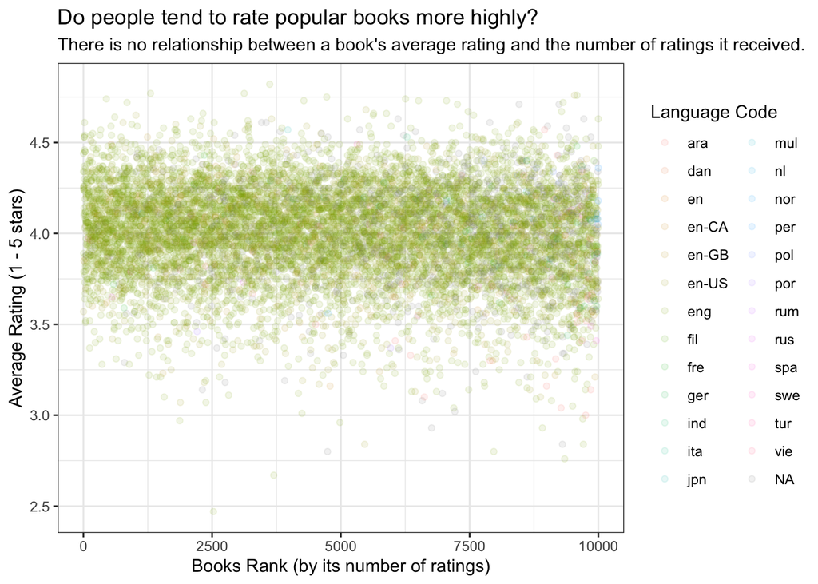

Figure 1: Do people tend to rate popular books more highly?

## Key Takeaway 2

**More than 80% of books on Goodreads are written in some variety of English.**

Table 1: How many books and what percent of books on Goodreads are written in English?

|  | Language Code | Count | Percent |
| --- | --- | --- | --- |
| 1 | ara | 64 | 0.64 |
| 2 | dan | 3 | 0.03 |
| 3 | en | 4 | 0.04 |
| 4 | en-CA | 58 | 0.58 |
| 5 | en-GB | 257 | 2.57 |
| 6 | en-US | 2070 | 20.7 |
| 7 | eng | 6341 | 63.41 |
| 8 | fil | 2 | 0.02 |
| 9 | fre | 25 | 0.25 |
| 10 | ger | 13 | 0.13 |

[output cut: 16 more lines]

## Key Takeaway 3

**YA books have been published since the year 1750 BC.**

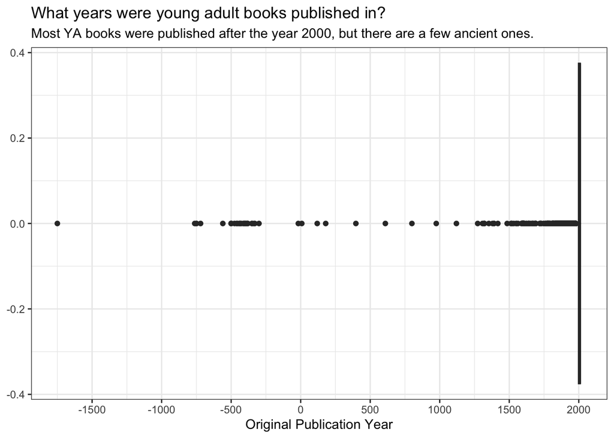

Figure 2: What years were YA books published in?

## Conclusion

There is so much to learn from the Goodreads dataset.

Through these data explorations, I answered everything I’ve ever wondered about Goodreads user habits, user tag trends, YA book trends, and more.

Perhaps looking at this dataset will reveal the next great read.

# References

Zając, Zygmunt (2017, Sept. 19). Github. https://github.com/zygmuntz/goodbooks-10k